# L’interrogation des données PostgreSQL

Razvan BIZOÏ

2024-11-23

# Librairies nécessaires

```r
library(RPostgres)
library(DBI)
library(DT)
```

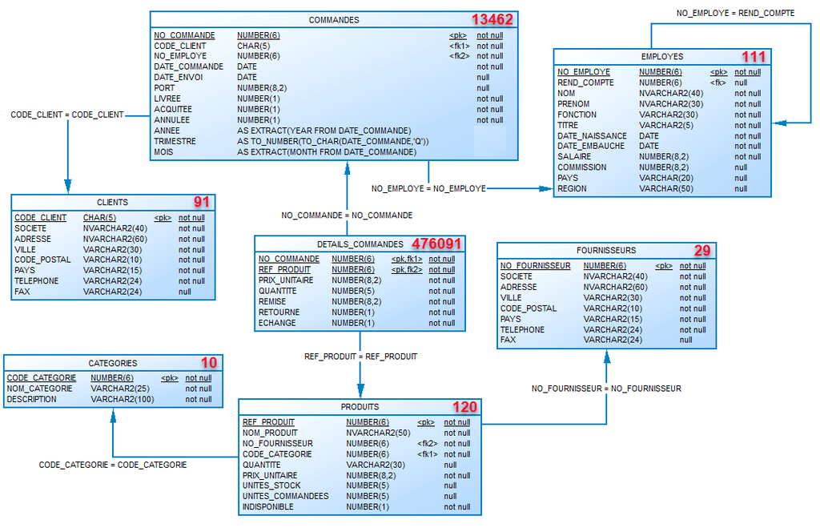

# Connexion à la base de données PostgreSQL `Cours`

```r
library(RPostgres)
library(DBI)

connection <- dbConnect(RPostgres::Postgres(), host=host, port=port, dbname=dbname, user=user, password=password)
```

# Projection

> > `SELECT [ ALL | DISTINCT ]`  
> > `{ [{ NOM_TABLE | ALIAS2 }.]* ,`  
> > `[ [{NOM_TABLE |ALIAS2}.]COLONNE1 [AS] ALIAS1[,...]}`  
> > `FROM NOM_TABLE ALIAS2`

```r
requette <- dbSendQuery(connection, "

                select fonction
                from employes

                        ")

donnees <- dbFetch(requette);dbHasCompleted(requette);dbClearResult(requette)
```

```
## [1] TRUE
```

```r
datatable(donnees,options = list(pageLength = 12, autoWidth = TRUE))
```

|  | fonction |
| --- | --- |
| 1 | Président |
| 2 | Vice-Président |
| 3 | Vice-Président |
| 4 | Chef des ventes |
| 5 | Chef des ventes |
| 6 | Chef des ventes |
| 7 | Chef des ventes |
| 8 | Chef des ventes |
| 9 | Chef des ventes |
| 10 | Représentant(e) |

[output cut: 101 more lines]

## Distinct

```r
requette <- dbSendQuery(connection, "

                SELECT DISTINCT FONCTION
                FROM EMPLOYES

                        ")

donnees <- dbFetch(requette);dbHasCompleted(requette);dbClearResult(requette)
```

```
## [1] TRUE
```

```r
datatable(donnees,options = list(pageLength = 12, autoWidth = TRUE))
```

|  | fonction |
| --- | --- |
| 1 | Vice-Président |
| 2 | Chef des ventes |
| 3 | Représentant(e) |
| 4 | Assistante commerciale |
| 5 | Président |

# Constantes

```r
requette <- dbSendQuery(connection, "

              SELECT 0 as c1, -1234567890 as c2, +1234567890 as c3, -123.456 as c4, +123.456 as c5, -1E+13 as c6

                        ")

donnees <- dbFetch(requette);dbHasCompleted(requette);dbClearResult(requette)
```

```
## [1] TRUE
```

```r
donnees
```

```
##   c1          c2         c3       c4      c5     c6
## 1  0 -1234567890 1234567890 -123.456 123.456 -1e+13
```

```r
requette <- dbSendQuery(connection, "

              SELECT -123 as c1, 456 as c2, +123 as c3, 456 as c4,-1E+13 as c5

                        ")

donnees <- dbFetch(requette);dbHasCompleted(requette);dbClearResult(requette)
```

```
## [1] TRUE
```

```r
donnees
```

```
##     c1  c2  c3  c4     c5
## 1 -123 456 123 456 -1e+13
```

```r
requette <- dbSendQuery(connection, "

              SELECT now() as Date

                        ")

donnees <- dbFetch(requette);dbHasCompleted(requette);dbClearResult(requette)
```

```
## [1] TRUE
```

```r
donnees
```

```
##                  date
## 1 2024-11-25 17:22:35
```

# Opérateur de concaténation

```r
requette <- dbSendQuery(connection, "

SELECT
    NO_EMPLOYE||' -- '||NOM||' -- '||PRENOM||' -- '||DATE_NAISSANCE  ListeEmployés,
    concat(NO_EMPLOYE,' -- ',NOM,' -- ',PRENOM)  ListeEmployés
FROM EMPLOYES
FETCH NEXT 5 ROWS ONLY

                        ")

donnees <- dbFetch(requette);dbHasCompleted(requette);dbClearResult(requette)
```

```
## [1] TRUE
```

```r
donnees
```

```
##                               listeemployés               listeemployés
## 1 37 -- Giroux -- Jean-Claude -- 1979-04-28 37 -- Giroux -- Jean-Claude
## 2      14 -- Fuller -- Andrew -- 1984-06-27      14 -- Fuller -- Andrew
## 3     18 -- Brasseur -- Hervé -- 1980-05-29     18 -- Brasseur -- Hervé
## 4    24 -- Buchanan -- Steven -- 1972-11-26    24 -- Buchanan -- Steven
## 5       95 -- Leger -- Pierre -- 1989-09-01       95 -- Leger -- Pierre
```

# Opérateurs arithmétiques

```r
requette <- dbSendQuery(connection, '

SELECT
    NOM_PRODUIT "Produit",
    PRIX_UNITAIRE*UNITES_STOCK "Stock",
    UNITES_COMMANDEES*12 "Commandes"
FROM PRODUITS
FETCH NEXT 5 ROWS ONLY

                        ')

donnees <- dbFetch(requette);dbHasCompleted(requette);dbClearResult(requette)
```

```
## [1] TRUE
```

```r
donnees
```

```
##              Produit Stock Commandes
## 1                Tea   100       240
## 2              Pears    40       120
## 3            Peaches    40       120
## 4          Pineapple    40       120
## 5 Cherry Pie Filling    40       120
```

```r
requette <- dbSendQuery(connection, '

              SELECT
                  NOM,
                  DATE_NAISSANCE,
                  DATE_NAISSANCE+1 "Jour 1",
                  DATE_NAISSANCE-1 "Jour -1",
                  extract(days from  (now()-DATE_NAISSANCE))/365 "jours"
              FROM EMPLOYES
              FETCH NEXT 5 ROWS ONLY

                        ')

donnees <- dbFetch(requette);dbHasCompleted(requette);dbClearResult(requette)
```

```
## [1] TRUE
```

```r
donnees
```

```
##        nom date_naissance     Jour 1    Jour -1    jours
## 1   Giroux     1979-04-28 1979-04-29 1979-04-27 45.61096
## 2   Fuller     1984-06-27 1984-06-28 1984-06-26 40.44110
## 3 Brasseur     1980-05-29 1980-05-30 1980-05-28 44.52329
## 4 Buchanan     1972-11-26 1972-11-27 1972-11-25 52.03288
## 5    Leger     1989-09-01 1989-09-02 1989-08-31 35.25753
```

# NULL - valeurs non renseignées

```r
requette <- dbSendQuery(connection, "

                SELECT NOM,
                      SALAIRE,
                      COMMISSION,
                      SALAIRE+COMMISSION as revenu
                FROM EMPLOYES

                        ")

donnees <- dbFetch(requette);dbHasCompleted(requette);dbClearResult(requette)
```

```
## [1] TRUE
```

```r
head(donnees,12)
```

```
##          nom salaire commission revenu
## 1     Giroux  150000         NA     NA
## 2     Fuller   96000         NA     NA
## 3   Brasseur  147000         NA     NA
## 4   Buchanan   13000      12940  25940
## 5      Leger   19000      11150  30150
## 6      Belin   10000      10640  20640
## 7   Chambaud   12000      11600  23600
## 8      Ragon   13000       5980  18980
## 9  Splingart   16000      16480  32480
## 10     Besse    9900        940  10840
## 11  Destenay    9900        790  10690
## 12  Letertre    5600       1890   7490
```

# Fonction `COALESCE`

```r
requette <- dbSendQuery(connection, "

              SELECT NOM,
                     SALAIRE,
                     COMMISSION,
                     COALESCE(COMMISSION,0) COMMISSION,
                     SALAIRE + COALESCE(COMMISSION,0) as revenu
              FROM EMPLOYES

                        ")

donnees <- dbFetch(requette);dbHasCompleted(requette);dbClearResult(requette)
```

```
## [1] TRUE
```

```r
head(donnees,12)
```

```
##          nom salaire commission commission revenu
## 1     Giroux  150000         NA          0 150000
## 2     Fuller   96000         NA          0  96000
## 3   Brasseur  147000         NA          0 147000
## 4   Buchanan   13000      12940      12940  25940
## 5      Leger   19000      11150      11150  30150
## 6      Belin   10000      10640      10640  20640
## 7   Chambaud   12000      11600      11600  23600
## 8      Ragon   13000       5980       5980  18980
## 9  Splingart   16000      16480      16480  32480
## 10     Besse    9900        940        940  10840
## 11  Destenay    9900        790        790  10690
## 12  Letertre    5600       1890       1890   7490
```

```r
requette <- dbSendQuery(connection, "

SELECT SOCIETE,
       COALESCE(FAX, 'Non affecté') as Fax
FROM CLIENTS

                        ")

donnees <- dbFetch(requette);dbHasCompleted(requette);dbClearResult(requette)
```

```
## [1] TRUE
```

```r
head(donnees,12)
```

```
##                                 societe            fax
## 1                 Consolidated Holdings  (71) 555-9199
## 2              Drachenblut Delikatessen    0241-059428
## 3                       Du monde entier 02.40.67.89.89
## 4                    Eastern Connection  (71) 555-3373
## 5                          Ernst Handel      7675-3426
## 6                    Familia Arquibaldo    Non affecté
## 7  FISSA Fabrica Inter. Salchichas S.A. (91) 555 55 93
## 8                     Folies gourmandes 03.20.16.10.17
## 9                        Folk och fä HB    Non affecté
## 10                       Frankenversand    089-0877451
## 11                  France restauration 02.40.32.21.20
## 12                       Franchi S.p.A.    011-4988261
```

# Tri du résultat d’une requête

> > `SELECT [ALL | DISTINCT]{*,[EXPRESSION1 [AS] ALIAS1[,...]}`  
> > `FROM NOM_TABLE`  
> > `ORDER BY`  
> > `[NOM_COLONNE1|ALIAS1|POSITION1|EXPRESSION1][ASC|DESC] [NULLS {FIRST|LAST}],`  
> > `[NOM_COLONNE2|ALIAS2|POSITION2|EXPRESSION2][ASC|DESC] [NULLS {FIRST|LAST}]`

```r
requette <- dbSendQuery(connection, "

              SELECT NOM,
                     PRENOM,
                     FONCTION
              FROM EMPLOYES
              ORDER BY NOM

                        ")

donnees <- dbFetch(requette)

dbHasCompleted(requette)
```

```
## [1] TRUE
```

```r
dbClearResult(requette)

datatable(donnees,options = list(pageLength = 12, autoWidth = TRUE))
```

|  | nom | prenom | fonction |
| --- | --- | --- | --- |
| 1 | Alvarez | Marcel | Représentant(e) |
| 2 | Arrambide | Jean Pierre | Représentant(e) |
| 3 | Aubert | Maria | Représentant(e) |
| 4 | Aubry | Jean-Claude | Représentant(e) |
| 5 | Barre | Jean-Paul | Représentant(e) |
| 6 | Bazart | Régis | Représentant(e) |
| 7 | Belin | Chantal | Chef des ventes |
| 8 | Berlioz | Jacques | Représentant(e) |
| 9 | Besse | José | Représentant(e) |
| 10 | Bettan | Henri-Michel | Représentant(e) |

[output cut: 101 more lines]

```r
requette <- dbSendQuery(connection, "

              SELECT
              NOM||' '||PRENOM as Employé,
              FONCTION
              FROM EMPLOYES
              ORDER BY NOM||' '||PRENOM ASC

                        ")

donnees <- dbFetch(requette);dbHasCompleted(requette);dbClearResult(requette)
```

```
## [1] TRUE
```

```r
datatable(donnees,options = list(pageLength = 12, autoWidth = TRUE))
```

|  | employé | fonction |
| --- | --- | --- |
| 1 | Alvarez Marcel | Représentant(e) |
| 2 | Arrambide Jean Pierre | Représentant(e) |
| 3 | Aubert Maria | Représentant(e) |
| 4 | Aubry Jean-Claude | Représentant(e) |
| 5 | Barre Jean-Paul | Représentant(e) |
| 6 | Bazart Régis | Représentant(e) |
| 7 | Belin Chantal | Chef des ventes |
| 8 | Berlioz Jacques | Représentant(e) |
| 9 | Besse José | Représentant(e) |
| 10 | Bettan Henri-Michel | Représentant(e) |

[output cut: 101 more lines]

```r
requette <- dbSendQuery(connection, "

              SELECT NOM_PRODUIT,
                    NO_FOURNISSEUR,
                    CODE_CATEGORIE
              FROM PRODUITS
              ORDER BY NO_FOURNISSEUR, CODE_CATEGORIE DESC

                        ")

donnees <- dbFetch(requette);dbHasCompleted(requette);dbClearResult(requette)
```

```
## [1] TRUE
```

```r
head(donnees,20)
```

```
##                         nom_produit no_fournisseur code_categorie
## 1                     Aniseed Syrup              1              2
## 2                              Chai              1              1
## 3                             Chang              1              1
## 4                Cherry Pie Filling              2              9
## 5                           Amandes              2              7
## 6                       Brownie Mix              2              3
## 7  Louisiana Fiery Hot Pepper Sauce              2              2
## 8         Louisiana Hot Spiced Okra              2              2
## 9            Chef Anton's Gumbo Mix              2              2
## 10     Chef Anton's Cajun Seasoning              2              2
## 11  Uncle Bob's Organic Dried Pears              3              7
## 12       Northwoods Cranberry Sauce              3              2
## 13     Grandma's Boysenberry Spread              3              2
## 14                             Corn              4              9
## 15                            Ikura              4              8
## 16                    Longlife Tofu              4              7
## 17                  Long Grain Rice              4              7
## 18                  Mishi Kobe Niku              4              6
## 19                           Scones              4              3
## 20                          Mustard              4              2
```

# Limitation d’enregistrements

```r
requette <- dbSendQuery(connection, "

              SELECT CODE_CATEGORIE,
                     NOM_CATEGORIE
              FROM CATEGORIES
                         FETCH FIRST 6 ROWS ONLY

                        ")

donnees <- dbFetch(requette);dbHasCompleted(requette);dbClearResult(requette)
```

```
## [1] TRUE
```

```r
donnees
```

```
##   code_categorie     nom_categorie
## 1              1          Boissons
## 2              2        Condiments
## 3              3          Desserts
## 4              4 Produits laitiers
## 5              5 Pâtes et céréales
## 6              6           Viandes
```

```r
requette <- dbSendQuery(connection, "

              SELECT CODE_CATEGORIE,
                     NOM_CATEGORIE
              FROM CATEGORIES
                      OFFSET 5 ROWS FETCH NEXT 3 ROWS ONLY

                        ")

donnees <- dbFetch(requette);dbHasCompleted(requette);dbClearResult(requette)
```

```
## [1] TRUE
```

```r
donnees
```

```
##   code_categorie             nom_categorie
## 1              6                   Viandes
## 2              7             Produits secs
## 3              8 Poissons et fruits de mer
```

```r
requette <- dbSendQuery(connection, "

              SELECT NOM_PRODUIT,
                     UNITES_STOCK
              FROM PRODUITS
              ORDER BY UNITES_STOCK DESC NULLS LAST
              FETCH NEXT 5 ROWS ONLY

                        ")

donnees <- dbFetch(requette);dbHasCompleted(requette);dbClearResult(requette)
```

```
## [1] TRUE
```

```r
donnees
```

```
##            nom_produit unites_stock
## 1         Potato Chips          200
## 2 Rhönbräu Klosterbier          125
## 3            Green Tea          125
## 4     Boston Crab Meat          123
## 5            Crab Meat          120
```

```r
requette <- dbSendQuery(connection, "

              SELECT NO_COMMANDE,
                     REF_PRODUIT,
                     QUANTITE,
                     PRIX_UNITAIRE
              FROM DETAILS_COMMANDES
                      FETCH NEXT 5 ROWS ONLY

                        ")

donnees <- dbFetch(requette);dbHasCompleted(requette);dbClearResult(requette)
```

```
## [1] TRUE
```

```r
donnees
```

```
##   no_commande ref_produit quantite prix_unitaire
## 1      215576         112      166         37.80
## 2      215576         113      192         65.76
## 3      215576          78      101         47.16
## 4      215576          47      119         63.24
## 5      215576          62      128         94.56
```

# `Atelier` – Interrogation des données

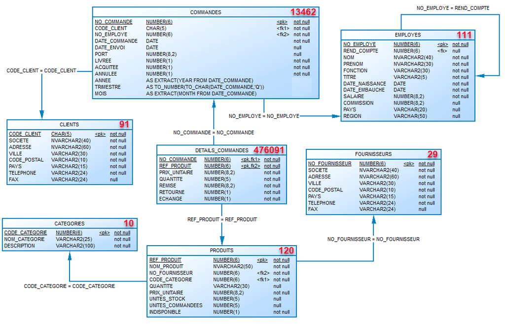

## Projection

Écrivez les requêtes vous permettant d’afficher :

1. Le nom, le prénom et la date de naissance de tous les employés de la société.
2. Le nom de la société, la ville et le pays de tous les fournisseurs.
3. La fonction de tous les employés.
4. Toutes les fonctions des employés de l’entreprise, chaque fonction doit être affichée une seule fois.
5. La liste des localités dans lesquelles la société a au moins un client.

## Opérateurs

Créez les requêtes vous permettant d’afficher :

1. Les produits commercialisés, la valeur du stock par produit et la valeur des produits commandés. Dans la table `PRODUITS`, vous trouvez les champs `UNITES_STOCK` et `UNITES_COMMANDEES` que vous multipliez par le `PRIX_UNITAIRE` pour retrouver les valeurs des deux stocks.
2. Le nom, le prénom, l’âge et l’ancienneté des employés, dans la société.
3. Le numéro de la commande, le temps écoulé entre la commande et la livraison de celle-ci ainsi que les frais de port.

## Les ordres de tri

1. Les employés par ordre alphabétique.
2. Les employés depuis le plus récemment embauché jusqu’au plus ancien.
3. Les fournisseurs dans l’ordre alphabétique de leur pays et ville de résidence.
4. Les employés par ordre alphabétique de leur fonction et du plus grand salaire au plus petit.
5. Les employés dans l’ordre de leur commission.